# Utilizing Machine Learning Principles for Human Verification through Image Classification

### Sunday, November 6, 2022

```python
# used for Jupyter Notebook - to access cv2
#!pip install opencv-python
```

```python
# load libaries
import numpy as np
import pandas as pd
import matplotlib as mpl
import matplotlib.pyplot as plt
from tabulate import tabulate
import seaborn as sns
# used for data pre-processing and model metrics
from sklearn.preprocessing import StandardScaler, minmax_scale
from sklearn.model_selection import train_test_split, GridSearchCV
from sklearn.metrics import mean_squared_error, mean_absolute_error, confusion_matrix, classification_report, roc_curve, roc_auc_score, accuracy_score, recall_score, precision_score, f1_score
# used to perform intial model
from sklearn.decomposition import PCA, NMF
from sklearn.linear_model import LogisticRegression
# used to perform optimization models
from sklearn.ensemble import RandomForestClassifier, GradientBoostingClassifier
# used for neural networks
import tensorflow as tf
from tensorflow import keras
from tensorflow.keras import Sequential
from tensorflow.keras.layers import Dense, Dropout
from tensorflow.keras.callbacks import EarlyStopping
from tensorflow.keras.datasets import mnist, cifar10
# used to set random seeds
from numpy.random import seed
# used to display an image in a window
import cv2
```

## 1. Introduction

Among the data science community, image classification problems are a huge topic in several sub-fields, where many methods have been developed. One major usage of image classification is for website protection measures by using the computer’s ability to identify whether a user is a robot or not. Many websites prompt users to select a certain type of image to prove whether they are a robot or not by correctly selecting the appropriate image(s). However, with machine learning algorithms, we questioned the integrity of these website protectors and how great of an accuracy are they against humans at passing the test. According to an article on CAPTCHA by the Baymard Institute (2018), humans tend to fail the test around 8-29% of the time. This suggests that humans tend to misclassify images 18.5% of the time on average. As for our classification analysis, we are examining whether a computer model can be more effective at identifying if an image is a non-living or a living object than a human using the `CIFAR-10` dataset.

```python
# Load data.
(X_train, y_train), (X_test, y_test) = cifar10.load_data()

# Note: It was easier to import the data directly as training and test sets.
```

## 2. Data Collection

The `CIFAR-10` image dataset is a widely used dataset for machine learning and image recognition that consists of 10 class images (i.e., airplane, car, bird, cat, deer, dog, frog, horse, ship, and truck) each with 6,000 images per class and 32x32 color pixels. The data was accessed using tensorflow.keras package, where the data was additionally split into training and test datasets among 2 feature matrices and 2 target vectors with 5,000 and 1,000 images, respectively.

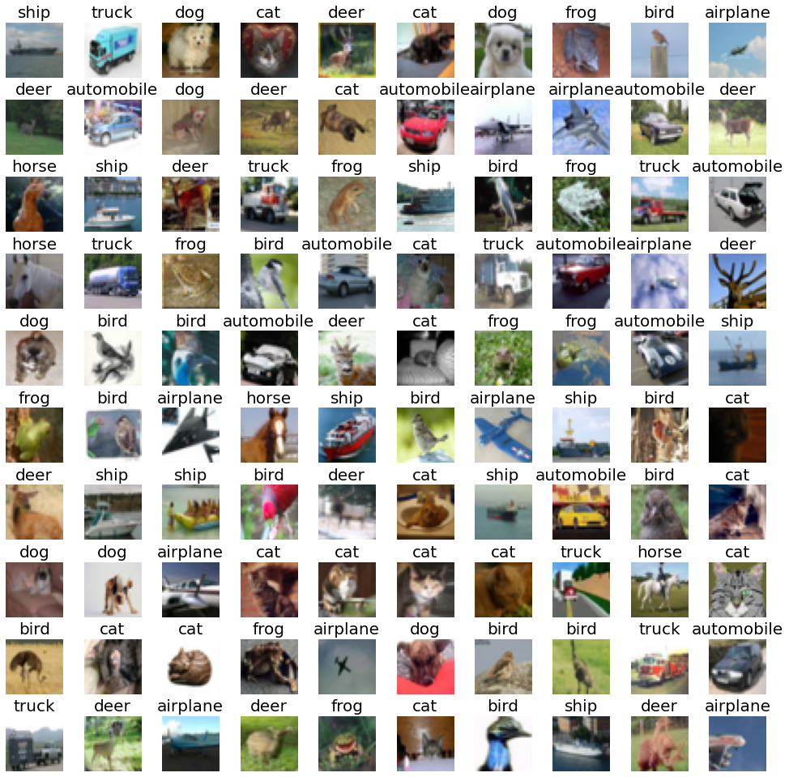

```python
labels = ['airplane', 'automobile', 'bird', 'cat', 'deer',
          'dog', 'frog', 'horse', 'ship', 'truck']

# Let's view more images in a grid format
# Define the dimensions of the plot grid
W_grid = 10
L_grid = 10
fig, axes = plt.subplots(L_grid, W_grid, figsize = (17,17))
# flaten the 15 x 15 matrix into 225 array
axes = axes.ravel()
# gets the length of the train dataset
n_train = len(X_train)

# Select a random number from 0 to n_train
    # create evenly spaces variables
for i in np.arange(0, W_grid * L_grid):
    # Select a random number
    index = np.random.randint(0, n_train)
    # read and display an image with the selected index
    axes[i].imshow(X_train[index,1:])
    label_index = int(y_train[index])
    axes[i].set_title(labels[label_index], fontsize = 20)
    axes[i].axis('off')

plt.subplots_adjust(hspace=0.4)
```

We converted the classifications from multiple to binary by relabeling the image classes airplane, automobile, ship, and truck (i.e., 0, 1, 8, and 9) as non-living objects (i.e., 1), 1 while bird, cat, deer, dog, frog, and horse (i.e., 2, 3, 4, 5, 6, and 7) as living objects (i.e., 0) in our 2 target vectors.

```python
## Create binary variable
# Create vector of the indices that are labeled as object
object_idx = [0,1,8,9]
# Set objects index = 1, ifelse 0 when an animal for both the train and test
y_train_cl = np.where(y_train == object_idx, 1, 0).max(axis=1).reshape(-1,1)
y_test_cl = np.where(y_test == object_idx, 1, 0).max(axis=1).reshape(-1,1)
```

## 3. Exploratory Data Analysis (EDA)

Before any data manipulations could be done, we performed some exploratory data analysis, where we found two distinct observations:

(1) the distribution for each of our image classes seems to have normalized pixels for both training and test datasets shown in the figure below.

[figure not shown]

```python
fig, axs = plt.subplots(1,2,figsize=(25,8))
# Count plot for training set
sns.countplot(x=y_train.ravel(), ax=axs[0])
axs[0].set_title('Distribution of training data', fontweight="bold", size=20)
axs[0].set_xlabel('Classes', size=12)
axs[0].set_ylabel('count', size=12)
# Count plot for testing set
sns.countplot(x=y_test.ravel(), ax=axs[1])
axs[1].set_title('Distribution of Testing data', fontweight="bold", size=20)
axs[1].set_xlabel('Classes', size=12)
axs[1].set_ylabel('count', size=12)
# adds caption
#txt = "Figure 1 (a-b)"
#fig.text(0.5, .0001, txt, ha='left', fontsize = 15, fontweight="bold")
plt.show()
```

(2) the range of the top five most prominent colors used along with its average color for each an classified and misclassified object and non-object class.

```python
# Extract object indices
object_idx_train = np.where(y_train == object_idx)[0]
object_idx_test = np.where(y_test == object_idx)[0]
# Filters both the train and test sets feature matrices by only object indices
X_train_object = X_train[object_idx_train]
X_test_object = X_test[object_idx_test]
```

Here we examine an image of a truck being misclassified as an non-object.

```
[0]
```

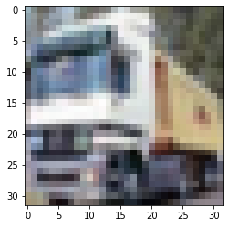

```python
# Selected image - truck misclassified
plt.imshow(X_train_object[0])
print(y_train_cl[0])
```

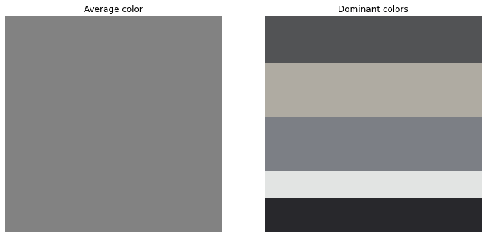

```python
# Examine Color Platte Summary
img = X_train_object[0]
pixels = np.float32(img.reshape(-1, 3))
average = X_train_object[0].mean(axis=0).mean(axis=0)
n_colors = 5
criteria = (cv2.TERM_CRITERIA_EPS + cv2.TERM_CRITERIA_MAX_ITER, 200, .1)
flags = cv2.KMEANS_RANDOM_CENTERS
_, labels, palette = cv2.kmeans(pixels, n_colors, None, criteria, 10, flags)
_, counts = np.unique(labels, return_counts=True)
dominant = palette[np.argmax(counts)]
avg_patch = np.ones(shape=img.shape, dtype=np.uint8)*np.uint8(average)
indices = np.argsort(counts)[::-1]
freqs = np.cumsum(np.hstack([[0], counts[indices]/float(counts.sum())]))
rows = np.int_(img.shape[0]*freqs)
dom_patch = np.zeros(shape=img.shape, dtype=np.uint8)

for i in range(len(rows) - 1):
    dom_patch[rows[i]:rows[i + 1], :, :] += np.uint8(palette[indices[i]])

fig, (ax0, ax1) = plt.subplots(1, 2, figsize=(12,6))
ax0.imshow(avg_patch)
ax0.set_title('Average color')
ax0.axis('off')
ax1.imshow(dom_patch)
ax1.set_title('Dominant colors')
ax1.axis('off')
plt.show(fig)
```

As a result, the top five most prominent colors used are a medium-dark grey scaling.

Here we examine an image of a ship being correctly classified as an object.

```
[1]
```

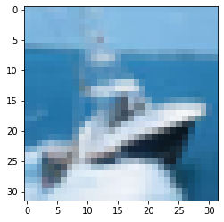

```python
# Selected image - ship
plt.imshow(X_train_object[4])
print(y_train_cl[4])
```

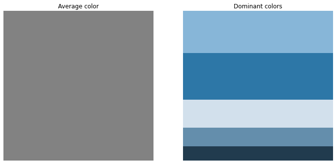

```python
# Examine Color Platte Summary
img = X_train_object[4]
pixels = np.float32(img.reshape(-1, 3))
average = X_train_object[0].mean(axis=0).mean(axis=0)
n_colors = 5
criteria = (cv2.TERM_CRITERIA_EPS + cv2.TERM_CRITERIA_MAX_ITER, 200, .1)
flags = cv2.KMEANS_RANDOM_CENTERS
_, labels, palette = cv2.kmeans(pixels, n_colors, None, criteria, 10, flags)
_, counts = np.unique(labels, return_counts=True)
dominant = palette[np.argmax(counts)]
avg_patch = np.ones(shape=img.shape, dtype=np.uint8)*np.uint8(average)
indices = np.argsort(counts)[::-1]
freqs = np.cumsum(np.hstack([[0], counts[indices]/float(counts.sum())]))
rows = np.int_(img.shape[0]*freqs)
dom_patch = np.zeros(shape=img.shape, dtype=np.uint8)

for i in range(len(rows) - 1):
    dom_patch[rows[i]:rows[i + 1], :, :] += np.uint8(palette[indices[i]])

fig, (ax0, ax1) = plt.subplots(1, 2, figsize=(12,6))
ax0.imshow(avg_patch)
ax0.set_title('Average color')
ax0.axis('off')
ax1.imshow(dom_patch)
ax1.set_title('Dominant colors')
ax1.axis('off')
plt.show(fig)
```

As a result, the top five most prominent colors used are a medium-dark blue scaling.

Here we examine an image of a bird being misclassified as an object.

```
[1]
```

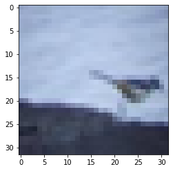

```python
# Selected image - bird misclassified
plt.imshow(X_train[~object_idx_train][2])
print(y_train_cl[2])
```

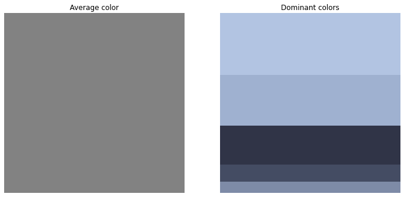

```python
# Examine Color Platte Summary
img2 = X_train[~object_idx_train][2]
pixels = np.float32(img2.reshape(-1, 3))
average = X_train_object[0].mean(axis=0).mean(axis=0)
n_colors = 5
criteria = (cv2.TERM_CRITERIA_EPS + cv2.TERM_CRITERIA_MAX_ITER, 200, .1)
flags = cv2.KMEANS_RANDOM_CENTERS
_, labels, palette = cv2.kmeans(pixels, n_colors, None, criteria, 10, flags)
_, counts = np.unique(labels, return_counts=True)
dominant = palette[np.argmax(counts)]
avg_patch = np.ones(shape=img2.shape, dtype=np.uint8)*np.uint8(average)
indices = np.argsort(counts)[::-1]
freqs = np.cumsum(np.hstack([[0], counts[indices]/float(counts.sum())]))
rows = np.int_(img2.shape[0]*freqs)
dom_patch = np.zeros(shape=img2.shape, dtype=np.uint8)

for i in range(len(rows) - 1):
    dom_patch[rows[i]:rows[i + 1], :, :] += np.uint8(palette[indices[i]])

fig, (ax0, ax1) = plt.subplots(1, 2, figsize=(12,6))
ax0.imshow(avg_patch)
ax0.set_title('Average color')
ax0.axis('off')
ax1.imshow(dom_patch)
ax1.set_title('Dominant colors')
ax1.axis('off')
plt.show(fig)
```

As a result, the top five most prominent colors used are a medium-dark grey-blue scaling.

Here we examine an image of a deer being correctly classified as an non-object.

```
[0]
```

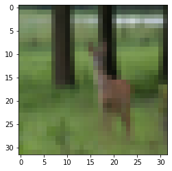

```python
# Selected image - deer
plt.imshow(X_train[~object_idx_train][18])
print(y_train_cl[18])
```

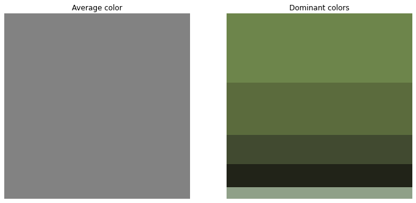

```python
# Examine Color Platte Summary
img2 = X_train[~object_idx_train][18]
pixels = np.float32(img2.reshape(-1, 3))
average = X_train_object[0].mean(axis=0).mean(axis=0)
n_colors = 5
criteria = (cv2.TERM_CRITERIA_EPS + cv2.TERM_CRITERIA_MAX_ITER, 200, .1)
flags = cv2.KMEANS_RANDOM_CENTERS
_, labels, palette = cv2.kmeans(pixels, n_colors, None, criteria, 10, flags)
_, counts = np.unique(labels, return_counts=True)
dominant = palette[np.argmax(counts)]
avg_patch = np.ones(shape=img2.shape, dtype=np.uint8)*np.uint8(average)
indices = np.argsort(counts)[::-1]
freqs = np.cumsum(np.hstack([[0], counts[indices]/float(counts.sum())]))
rows = np.int_(img2.shape[0]*freqs)
dom_patch = np.zeros(shape=img2.shape, dtype=np.uint8)

for i in range(len(rows) - 1):
    dom_patch[rows[i]:rows[i + 1], :, :] += np.uint8(palette[indices[i]])

fig, (ax0, ax1) = plt.subplots(1, 2, figsize=(12,6))
ax0.imshow(avg_patch)
ax0.set_title('Average color')
ax0.axis('off')
ax1.imshow(dom_patch)
ax1.set_title('Dominant colors')
ax1.axis('off')
plt.show(fig)
```

As a result, the top five most prominent colors used are a medium-dark green scaling.

## 4. Data Pre-processing

Before performing any model analysis, we had reshaped the dimensions of our images to be a 2D array for both the training and test datasets from 4D to easily couple the information across the dimensions. Without this step, the data wouldn’t be able to process and learn the information on a row-by-row basis.

```python
# reshape dimensions to be 2d array for both the train and test sets
nsamples_train, nx, ny, nrgb = X_train.shape
X_train_2d = X_train.reshape((nsamples_train,nx*ny*nrgb))
nsamples_test, nx, ny, nrgb = X_test.shape
X_test_2d = X_test.reshape((nsamples_test,nx*ny*nrgb))
```

Next, we split a portion of the training data to create our validation dataset to be used later in validating the test set results in the prevention of overfitting our training data. Resulting in the training set representing 2/3, and the validation and test set each representing 1/6 of the original dataset.

```python
# split training data to validate model testing
X_train, X_valid, y_train, y_valid = train_test_split(X_train_2d, y_train_cl, test_size=0.2, stratify=y_train_cl, random_state=100)
```

Lastly, despite the pixels showing normality, each feature matrix was normalized so that each image had an average value of 0 and a standard deviation of 1 to ensure that each feature would have equal weight when modeling.

```python
# perform normalization
scaler = StandardScaler()
X_train_standard = scaler.fit_transform(X_train)
X_valid_standard = scaler.transform(X_valid)
X_test_standard = scaler.transform(X_test_2d)
```

## 5. Initializing Model

As for our model analysis, we used the logistic regression method for our initial model baseline due to its probabilistic nature in predicting an event from a linear combination of predictors or in this case image features. In addition, this method is simple to implement, efficient to train, and easily interpretable in understanding the effects that each predictor or image feature has on the model. However, due to the simplicity of this method, logistic regression tends to overfit when using high-dimensional data and doesn’t support multicollinearity. Thus, we must be cautious since this data had 3,072 observations for each image and that pixels tend to be correlated due to items in images spanning multiple pixels.

```python
# set random seed
seed(2023)
tf.random.set_seed(2023)

# fit model
lr = LogisticRegression(max_iter=5000).fit(X_train_standard, y_train.flatten())
```

```python
## Computes predictions and probabilities
# Training set:
preds_lr_train = lr.predict(X_train_standard)
probs_lr_train = lr.predict_proba(X_train_standard)[:, 1]
# Validation set:
preds_lr_valid = lr.predict(X_valid_standard)
probs_lr_valid = lr.predict_proba(X_valid_standard)[:, 1]
# Test set:
preds_lr_test = lr.predict(X_test_standard)
probs_lr_test = lr.predict_proba(X_test_standard)[:, 1]
```

By using the Receiver Operating Characteristic (ROC) curve plot, we were able to visually test the data results for overfitting in the training set, which can be shown in the figure below.

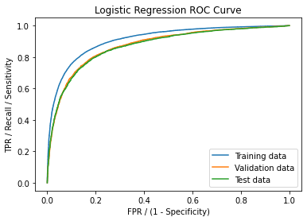

```python
# Plotting ROC Curves of Each dataset
fpr_lr_train, tpr_lr_train, _ = roc_curve(y_train, probs_lr_train)
fpr_lr_valid, tpr_lr_valid, _ = roc_curve(y_valid, probs_lr_valid)
fpr_lr_test, tpr_lr_test, _ = roc_curve(y_test_cl, probs_lr_test)

plt.plot(fpr_lr_train, tpr_lr_train, label = "Training data")
plt.plot(fpr_lr_valid, tpr_lr_valid, label = "Validation data")
plt.plot(fpr_lr_test, tpr_lr_test, label = "Test data")

plt.title('Logistic Regression ROC Curve')
plt.xlabel('FPR / (1 - Specificity)')
plt.ylabel('TPR / Recall / Sensitivity')
plt.legend(loc="lower right")

plt.show()
```

As a result, we noticed the curves the training and validation curves has a small relevant gap with the test set performing nearly identical performance as the validation set. This suggests the initial baseline model to be a good model fit.

## 6. Model Optimization

When optimizing our model, we performed neural networks due to their ability in resembling the inner workings of a human brain by using interconnected nodes or neurons in a layered structure, which is also known as deep learning covered underneath the machine learning process. In addition, neural networks are known to be more efficient, continuous learners, and multitasks. However, they are data-dependent and black-box in nature making it difficult for modifications and the comprehension of what’s going on behind the scenes. Despite the disadvantages, we wanted to see if this form of method could be used to improve the model’s overall accuracy and can out beat an actual human’s accuracy in comparison. As for the model metrics used in designing the model, we began with using one hidden layer with 29 neurons and a ReLU activation function, since it provided the best model accuracy when running these two features. Next, we decided to add a dropout layer since our model was overfitting to the training data with a rate of 36% since it gave the best model accuracy. Then, we decided to add an output layer with a sigmoid activation function since our model is performing a binary classification. Afterward, the model was compiled using a Stochastic Gradient Descent (SGD) optimizer since image classification models tend to optimize better with SGD than the Adam optimizer because it generalizes better despite being slower. In addition, the loss function was set to use a binary cross entropy because as entioned previously, this is a binary classification problem. Lastly, we decided to use a batch size of 200 and 59 epochs since it gave the best model accuracy after experimenting with the two metrics for several other combinations of values.

```python
# set random seed
seed(2023)
tf.random.set_seed(2023)

# design
model_nn = Sequential()
model_nn.add(Dense(29, activation='relu', input_shape=(X_train_standard.shape[1], )))
model_nn.add(Dropout(rate=.36))
model_nn.add(Dense(1, activation='sigmoid'))
model_nn.summary()
model_nn.compile(optimizer='sgd',
              loss='binary_crossentropy',
              metrics=['accuracy'])

# fit model
history = model_nn.fit(X_train_standard, y_train, epochs=59, batch_size=200, verbose=0,
                    validation_data=(X_valid_standard, y_valid))
```

```
Model: "sequential"
_________________________________________________________________
 Layer (type)                Output Shape              Param #
=================================================================
 dense (Dense)               (None, 29)                89117

 dropout (Dropout)           (None, 29)                0

 dense_1 (Dense)             (None, 1)                 30

=================================================================
Total params: 89,147
Trainable params: 89,147
Non-trainable params: 0
_________________________________________________________________
```

We used the loss function to vertify the best model parameters. This function was used to determine how well the model evaluated the data from overfitting by plotting it against the number for epoch.

```
['loss', 'accuracy']
[0.30113768577575684, 0.8812000155448914]
```

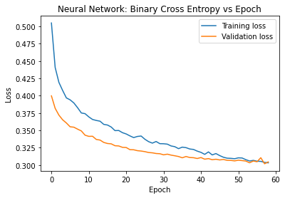

```python
# Loss (cross-entropy) and accuracy using valid set
print(model_nn.metrics_names)
print(model_nn.evaluate(X_test_standard, y_test_cl, verbose=0))

# checks loss
plt.plot(history.history['loss'], label='Training loss')
plt.plot(history.history['val_loss'], label='Validation loss')

plt.title('Neural Network: Binary Cross Entropy vs Epoch')
plt.ylabel('Loss')
plt.xlabel('Epoch')
plt.legend()
```

Although we are aware of this unsual observation, we concluded the fitness of the model to be good enough for the purposes of our model analysis. Moving forward, we used examined the model's accuarcy being improved based on the epoch and ROC curves to examine the model performance further.

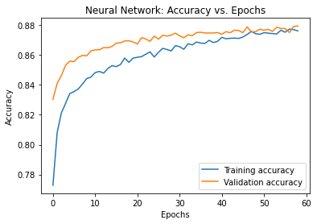

```python
# checks accuracy
plt.plot(history.history['accuracy'], label='Training accuracy')
plt.plot(history.history['val_accuracy'], label='Validation accuracy')
plt.title('Neural Network: Accuracy vs. Epochs')
plt.xlabel('Epochs')
plt.ylabel('Accuracy')
plt.legend()
```

As a result, we noticed the model seems to be overfitting initially since the validation data curve was projecting higher than the training data curve. However, the validation curve begins to minimize over time as the epoch number increases toward 65 at which the model’s overfitting was nearly removed, where results similar dip below the training curve.

```python
## Computes predictions and probabilities
# Training set:
probs_nn_train = model_nn.predict(X_train_standard)
preds_nn_train = np.where(probs_nn_train > 0.5, 1, 0 )
# Validation set:
probs_nn_valid = model_nn.predict(X_valid_standard)
preds_nn_valid = np.where(probs_nn_valid > 0.5, 1, 0 )
# Test set:
probs_nn_test = model_nn.predict(X_test_standard)
preds_nn_test = np.where(probs_nn_test > 0.5, 1, 0 )
```

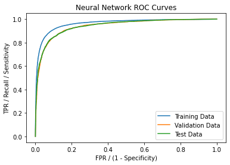

```python
# Plotting ROC Curves of Each dataset
fpr_nn_train, tpr_nn_train, _lr_train = roc_curve(y_train, probs_nn_train)
fpr_nn_valid, tpr_nn_valid, _lr_valid = roc_curve(y_valid, probs_nn_valid)
fpr_nn_test, tpr_nn_test, _lr_test = roc_curve(y_test_cl, probs_nn_test)

plt.plot(fpr_nn_train, tpr_nn_train, label = "Training Data")
plt.plot(fpr_nn_valid, tpr_nn_valid, label = "Validation Data")
plt.plot(fpr_nn_test, tpr_nn_test, label = "Test Data")
plt.title('Neural Network ROC Curves')
plt.xlabel('FPR / (1 - Specificity)')
plt.ylabel('TPR / Recall / Sensitivity')
plt.legend(loc="lower right")
plt.show()
```

When examining the neural network’s ROC curve plot, we notice the results coincide with the model performance being very similar with little to no overfit in the training data. Overall, we found that using neural networks as our optimization model produced roughly 88% test accuracy in image classification for our test dataset. Thus, suggesting this model is a better fit than our baseline model, which is examined further in the next section.

## 7. Compare Model Performances

Here we examined the model performances of both methods by first examining their ROC curve plots along with their Area Under the Curve (AUC) values. We used the ROC curve plots and AUC values to compare both model performances visually and numerically, respectively in the figure below. The ROC curve plot measures the model performance by plotting its False Positive Rate (FPR) versus its True Positive Rate (TPR) to determine whether the model can appropriately account for the classification. FPR also known as (1- Specificity) accounts for the rate at which an image was inaccurately classified, in other words when an image was classified as a non-living object when being a living object. TPR also known as Sensitivity or Recall accounts for the rate at which all the relevant image classes within the dataset are determined, in other words when an image was classified as a non-living object when being a non-living object. Ideally, we want the model to perform with a TPR of 1 and an FPR of 0, which is an asymptote sloping along the x and y axes on the upper-left-most corner of a graph. In addition, the AUC value is a metric falling within the range of 0 to 1 used to numerically measure a model’s ROC curve with 1 being the highest possible value indicating perfect model performance.

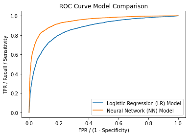

```python
# Plot
fpr_lr, tpr_lr, _lr = roc_curve(y_test_cl, probs_lr_test)
fpr_nn, tpr_nn, _nn = roc_curve(y_test_cl, probs_nn_test)

plt.plot(fpr_lr, tpr_lr, label = "Logistic Regression (LR) Model")
plt.plot(fpr_nn, tpr_nn, label = "Neural Network (NN) Model")

plt.title("ROC Curve Model Comparison")
plt.legend(loc="lower right")
plt.xlabel('FPR / (1 - Specificity)')
plt.ylabel('TPR / Recall / Sensitivity')
plt.show()
```

As a result, we noticed that the neural network model had outperformed the logistic regression model. Based on the ROC curve plot, the neural networks performed way closer at almost capturing all its true positives, while minimizing its false positive rate. Based on the AUC values, the neural network model exceeded the logistic regression model by scoring 0.14 higher with a 0.94 AUC value.

Secondly, we examined the model performances of both methods in terms of accuracy, precision, recall, and f1-score, where we used accuracy as our model metric in determining the better-fitted model. Accuracy is a metric that measures the ability to how close the model can measure its true value. It was used as our metric to be ultimately compared against the performance of a human’s ability in accurately assessing image classification. However, we are aware that accuracy isn’t always the best metric for assessing classification models, especially for imbalanced data. Thus, precision and recall were also used in assessing both models’ performances along with f1-score.

Precision was used to measure the data’s quality by having the ability to determine how well the model can return the correct image in a class. Recall, also known as TPR, was used to measure quantity by having the ability to determine how well the model can find all the relevant image classes within the dataset. F1-score is another form of metric that measures the model's accuracy while checking the balance for precision and recall, where it's often used for uneven class distributions. Since both models produced a f1-score above 0.7 the model is sufficient, where the neural network model is nearly 10% better than the logisitic model.

Using the table below, we can examine the model metrics across each model performed by its proportion rate.

```python
# table
print(tabulate([['Logistic Regression',
                 roc_auc_score(y_test_cl, preds_lr_test).round(3),
                 accuracy_score(y_test_cl, preds_lr_test).round(3),
                 precision_score(y_test_cl, preds_lr_test).round(3),
                 recall_score(y_test_cl, preds_lr_test).round(3),
                 f1_score(y_test_cl, preds_lr_test).round(3)
                 ],
               ['Neural Network',
                 roc_auc_score(y_test_cl, probs_nn_test).round(3),
                 accuracy_score(y_test_cl, preds_nn_test).round(3),
                 precision_score(y_test_cl, preds_nn_test).round(3),
                 recall_score(y_test_cl, preds_nn_test).round(3),
                f1_score(y_test_cl, preds_nn_test).round(3)
                 ]],
               headers=['Model (for Class = 1)', 'ROC AUC Score', 'Accuracy', 'Precision', 'Recall', 'F1-score']))
```

```
Model (for Class = 1)      ROC AUC Score    Accuracy    Precision    Recall    F1-score
-----------------------  ---------------  ----------  -----------  --------  ----------
Logistic Regression                0.797       0.81          0.78     0.731       0.755
Neural Network                     0.941       0.881         0.87     0.826       0.848
```

Thirdly, we examined the model performances of both methods in terms of their misclassification rate distribution. We were curious about how the model’s misclassification rate was affecting each class image. Using the table below, we can examine the distribution of the misclassification rate for each image class by its proporation rate.

```python
from collections import Counter
# filters the image classs that were misclassifed
lr_misclassified = preds_lr_test != y_test_cl.flatten()
nn_misclassified = preds_nn_test != y_test_cl

# table
print(tabulate([['Logistic Regression',
                 # Accounts for the number of misclassifications made by each image class for LR
                 Counter(y_test[lr_misclassified].flatten()).most_common()[0][1]/y_test_cl[y_test_cl==1].shape[0],
                 Counter(y_test[lr_misclassified].flatten()).most_common()[1][1]/y_test_cl[y_test_cl==1].shape[0],
                 Counter(y_test[lr_misclassified].flatten()).most_common()[2][1]/y_test_cl[y_test_cl!=1].shape[0],
                 Counter(y_test[lr_misclassified].flatten()).most_common()[3][1]/y_test_cl[y_test_cl!=1].shape[0],
                 Counter(y_test[lr_misclassified].flatten()).most_common()[4][1]/y_test_cl[y_test_cl!=1].shape[0],
                 Counter(y_test[lr_misclassified].flatten()).most_common()[5][1]/y_test_cl[y_test_cl!=1].shape[0],
                 Counter(y_test[lr_misclassified].flatten()).most_common()[6][1]/y_test_cl[y_test_cl!=1].shape[0],
                 Counter(y_test[lr_misclassified].flatten()).most_common()[7][1]/y_test_cl[y_test_cl!=1].shape[0],
                 Counter(y_test[lr_misclassified].flatten()).most_common()[8][1]/y_test_cl[y_test_cl==1].shape[0],
                 Counter(y_test[lr_misclassified].flatten()).most_common()[9][1]/y_test_cl[y_test_cl==1].shape[0]
                 ],
               ['Neural Network',
                # Accounts for the number of misclassifications made by each image class for NN
                Counter(y_test[nn_misclassified]).most_common()[0][1]/y_test_cl[y_test_cl==1].shape[0],
                Counter(y_test[nn_misclassified]).most_common()[1][1]/y_test_cl[y_test_cl==1].shape[0],
                Counter(y_test[nn_misclassified]).most_common()[2][1]/y_test_cl[y_test_cl!=1].shape[0],
                Counter(y_test[nn_misclassified]).most_common()[3][1]/y_test_cl[y_test_cl!=1].shape[0],
                Counter(y_test[nn_misclassified]).most_common()[4][1]/y_test_cl[y_test_cl!=1].shape[0],
                Counter(y_test[nn_misclassified]).most_common()[5][1]/y_test_cl[y_test_cl!=1].shape[0],
                Counter(y_test[nn_misclassified]).most_common()[6][1]/y_test_cl[y_test_cl!=1].shape[0],
                Counter(y_test[nn_misclassified]).most_common()[7][1]/y_test_cl[y_test_cl!=1].shape[0],
                Counter(y_test[nn_misclassified]).most_common()[8][1]/y_test_cl[y_test_cl==1].shape[0],
                Counter(y_test[nn_misclassified]).most_common()[9][1]/y_test_cl[y_test_cl==1].shape[0]
               ]]
               ,headers=['Model','Airplane','Autombile','Bird','Cat','Deer',
                         'Dog','Frog','Horse','Ship','Truck']
              ))
```

```
Model                  Airplane    Autombile       Bird        Cat       Deer     Dog       Frog      Horse     Ship    Truck
-------------------  ----------  -----------  ---------  ---------  ---------  ------  ---------  ---------  -------  -------
Logistic Regression      0.0815        0.073  0.0413333  0.0336667  0.0295     0.0285  0.0226667  0.0198333  0.02475  0.01625
Neural Network           0.061         0.042  0.0243333  0.0226667  0.0206667  0.016   0.0145     0.014      0.01525  0.0105
```

## 8. Conclusion, Limitations, and Future Work

**Conclusion:** Our team proposes that the optimization model using neural networks as to be the most effective for image classification. Based on our results, it has the best overall model performance in comparison to the logistic regression. In addition, using the Baymard Institute of 2018 article average statistic, the model performs 6.6% more accurately than a human does on average. Thus, outperforming most humans in accurately assessing image classification.

**Limitatons:** Due to the unknown nature of our fit, we presume conducting further investigation in its development would help account for possibility improving the model's accuracy. Based on some articles, this phenomenon could be caused by a number of factors. One being the data between the training and validation must be different in some way. Thus, most suggest to reevaluate the data distribution/ data splitting method, add more data for the validation set, or check the usage of the performance metric being appropriate.

## 9. References

1. Scott, E., January 18, 2018. CAPTCHAs Have an 8% Failure Rate, and 29% if Case Sensitive, Baymard Institute
   - [https://baymard.com/blog/captchas-in-checkout]
2. N, B. 2022, October 3-10, 2022. [Lecture recording]. Notre Dame University.
   - Dimensionality Reduction in Images
     - [https://notredame.hosted.panopto.com/Panopto/Pages/Viewer.aspx?id=c1370d42-4327-48e0-aede-af2400100d7c]
   - Deep Learning
     - [https://notredame.hosted.panopto.com/Panopto/Pages/Viewer.aspx?id=0473db1f-6a1a-433b-b289-af2b001518b1]
3. November 6, 2022. The Advantages and Disadvantages of Neural Networks, myayanblog
   - [https://www.myayan.com/advantages-and-disadvantages-of-neural-networks]
4. Koehren, W., September 15, 2022. Use Precision and Recall to Evaluate Your Classification Model When Accurately Isn’t Enough, Built In
   - [https://builtin.com/data-science/precision-and-recall]
5. Soleymani, A., Apirl 7, 2022. Your validation loss is lower than your training loss? This is way!. Towards Data Science
   - https://towardsdatascience.com/what-your-validation-loss-is-lower-than-your-training-loss-this-is-why-5e92e0b1747e